# Optimal Treatment Analysis

## Outcome Variable

**Outcome Variable:** haz

## Predictor Variables

**Intervention Variable:** nchldlt5

**Adjustment Set:**

- arm
- W_mage
- meducyrs
- feducyrs
- hhwealth_quart
- hfoodsec
- W_mhtcm
- W_nrooms
- W_parity
- impfloor
- impsan
- safeh20
- delta_W_mage
- delta_meducyrs
- delta_feducyrs
- delta_hhwealth_quart
- delta_hfoodsec
- delta_W_mhtcm
- delta_W_nrooms
- delta_W_parity
- delta_impfloor
- delta_impsan
- delta_safeh20

## Stratifying Variables

The analysis was stratified on these variable(s):

- agecat
- studyid
- country

## Data Summary

| agecat | studyid | country | nchldlt5 | n_cell | n |
| --- | --- | --- | --- | --- | --- |
| Birth | ki1000108-IRC | INDIA | 1 | 84 | 274 |
| Birth | ki1000108-IRC | INDIA | 2+ | 190 | 274 |
| Birth | ki1017093c-NIH-Crypto | BANGLADESH | 1 | 18 | 19 |
| Birth | ki1017093c-NIH-Crypto | BANGLADESH | 2+ | 1 | 19 |
| Birth | kiGH5241-JiVitA-3 | BANGLADESH | 1 | 12104 | 12571 |
| Birth | kiGH5241-JiVitA-3 | BANGLADESH | 2+ | 467 | 12571 |
| 6 months | ki1000108-IRC | INDIA | 1 | 89 | 288 |
| 6 months | ki1000108-IRC | INDIA | 2+ | 199 | 288 |
| 6 months | ki1017093b-PROVIDE | BANGLADESH | 1 | 426 | 435 |
| 6 months | ki1017093b-PROVIDE | BANGLADESH | 2+ | 9 | 435 |
| 6 months | ki1017093c-NIH-Crypto | BANGLADESH | 1 | 507 | 512 |
| 6 months | ki1017093c-NIH-Crypto | BANGLADESH | 2+ | 5 | 512 |
| 6 months | ki1066203-TanzaniaChild2 | TANZANIA, UNITED REPUBLIC OF | 1 | 1391 | 1453 |
| 6 months | ki1066203-TanzaniaChild2 | TANZANIA, UNITED REPUBLIC OF | 2+ | 62 | 1453 |
| 6 months | ki1148112-LCNI-5 | MALAWI | 1 | 390 | 453 |
| 6 months | ki1148112-LCNI-5 | MALAWI | 2+ | 63 | 453 |
| 6 months | kiGH5241-JiVitA-3 | BANGLADESH | 1 | 10887 | 11252 |
| 6 months | kiGH5241-JiVitA-3 | BANGLADESH | 2+ | 365 | 11252 |
| 24 months | ki1000108-IRC | INDIA | 1 | 89 | 290 |
| 24 months | ki1000108-IRC | INDIA | 2+ | 201 | 290 |
| 24 months | ki1017093b-PROVIDE | BANGLADESH | 1 | 423 | 431 |
| 24 months | ki1017093b-PROVIDE | BANGLADESH | 2+ | 8 | 431 |
| 24 months | ki1017093c-NIH-Crypto | BANGLADESH | 1 | 357 | 361 |
| 24 months | ki1017093c-NIH-Crypto | BANGLADESH | 2+ | 4 | 361 |
| 24 months | ki1066203-TanzaniaChild2 | TANZANIA, UNITED REPUBLIC OF | 1 | 5 | 5 |
| 24 months | ki1066203-TanzaniaChild2 | TANZANIA, UNITED REPUBLIC OF | 2+ | 0 | 5 |
| 24 months | ki1148112-LCNI-5 | MALAWI | 1 | 283 | 327 |
| 24 months | ki1148112-LCNI-5 | MALAWI | 2+ | 44 | 327 |
| 24 months | kiGH5241-JiVitA-3 | BANGLADESH | 1 | 5454 | 5673 |
| 24 months | kiGH5241-JiVitA-3 | BANGLADESH | 2+ | 219 | 5673 |

The following strata were considered:

- agecat: 24 months, studyid: ki1000108-IRC, country: INDIA
- agecat: 24 months, studyid: ki1017093b-PROVIDE, country: BANGLADESH
- agecat: 24 months, studyid: ki1017093c-NIH-Crypto, country: BANGLADESH
- agecat: 24 months, studyid: ki1066203-TanzaniaChild2, country: TANZANIA, UNITED REPUBLIC OF
- agecat: 24 months, studyid: ki1148112-LCNI-5, country: MALAWI
- agecat: 24 months, studyid: kiGH5241-JiVitA-3, country: BANGLADESH
- agecat: 6 months, studyid: ki1000108-IRC, country: INDIA
- agecat: 6 months, studyid: ki1017093b-PROVIDE, country: BANGLADESH
- agecat: 6 months, studyid: ki1017093c-NIH-Crypto, country: BANGLADESH
- agecat: 6 months, studyid: ki1066203-TanzaniaChild2, country: TANZANIA, UNITED REPUBLIC OF
- agecat: 6 months, studyid: ki1148112-LCNI-5, country: MALAWI
- agecat: 6 months, studyid: kiGH5241-JiVitA-3, country: BANGLADESH
- agecat: Birth, studyid: ki1000108-IRC, country: INDIA
- agecat: Birth, studyid: ki1017093c-NIH-Crypto, country: BANGLADESH
- agecat: Birth, studyid: kiGH5241-JiVitA-3, country: BANGLADESH

### Dropped Strata

Some strata were dropped due to rare outcomes:

- agecat: Birth, studyid: ki1017093c-NIH-Crypto, country: BANGLADESH
- agecat: 24 months, studyid: ki1017093c-NIH-Crypto, country: BANGLADESH
- agecat: 24 months, studyid: ki1066203-TanzaniaChild2, country: TANZANIA, UNITED REPUBLIC OF

## Methods Detail

We’re interested in the causal parameters $E[Y_a]$ for all values of $a \in \mathcal{A}$. These parameters represent the mean outcome if, possibly contrary to fact, we intervened to set all units to have $A=a$. Under the randomization and positivity assumptions, these are identified by the statistical parameters $\psi_a=E_W[E_{Y|A,W}(Y|A=a,W)]$. In addition, we’re interested in the mean of $Y$, $E[Y]$ under no intervention (the observed mean). We will estimate these parameters by using SuperLearner to fit the relevant likelihood factors – $E_{Y|A,W}(Y|A=a,W)$ and $p(A=a|W)$, and then updating our likelihood fit using a joint TMLE.

For unadjusted analyses ($W=\{\}$), initial likelihoods were estimated using Lrnr_glm to estimate the simple $E(Y|A)$ and Lrnr_mean to estimate $p(A)$. For adjusted analyses, a small library containing Lrnr_glmnet, Lrnr_xgboost, and Lrnr_mean was used.

Having estimated these parameters, we will then use the delta method to estimate relative risks and attributable risks relative to a prespecified baseline level of $A$.

# Results Detail

## Results Plots

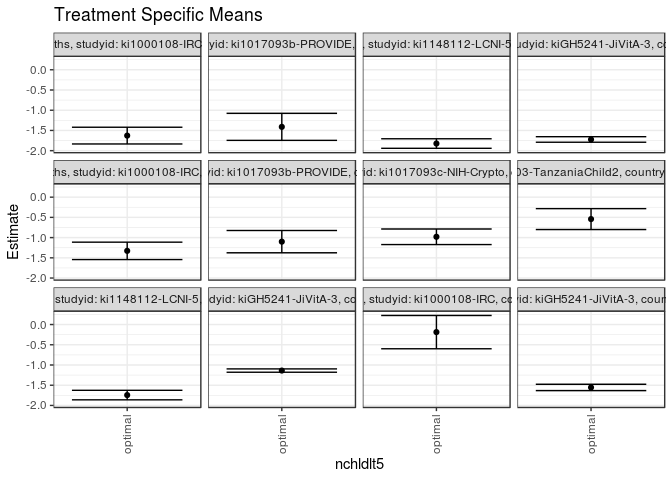

## Results Table

### Parameter: TSM

| agecat | studyid | country | intervention_level | baseline_level | estimate | ci_lower | ci_upper |
| --- | --- | --- | --- | --- | --- | --- | --- |
| Birth | ki1000108-IRC | INDIA | optimal | observed | -0.1869719 | -0.5986510 | 0.2247072 |
| Birth | kiGH5241-JiVitA-3 | BANGLADESH | optimal | observed | -1.5549095 | -1.6334464 | -1.4763726 |
| 6 months | ki1000108-IRC | INDIA | optimal | observed | -1.3274418 | -1.5424765 | -1.1124070 |
| 6 months | ki1017093b-PROVIDE | BANGLADESH | optimal | observed | -1.1001555 | -1.3754966 | -0.8248144 |
| 6 months | ki1017093c-NIH-Crypto | BANGLADESH | optimal | observed | -0.9797707 | -1.1720611 | -0.7874804 |
| 6 months | ki1066203-TanzaniaChild2 | TANZANIA, UNITED REPUBLIC OF | optimal | observed | -0.5420114 | -0.8005817 | -0.2834411 |
| 6 months | ki1148112-LCNI-5 | MALAWI | optimal | observed | -1.7438722 | -1.8615518 | -1.6261926 |
| 6 months | kiGH5241-JiVitA-3 | BANGLADESH | optimal | observed | -1.1379163 | -1.1792891 | -1.0965435 |
| 24 months | ki1000108-IRC | INDIA | optimal | observed | -1.6277652 | -1.8342976 | -1.4212328 |
| 24 months | ki1017093b-PROVIDE | BANGLADESH | optimal | observed | -1.4114553 | -1.7457379 | -1.0771727 |
| 24 months | ki1148112-LCNI-5 | MALAWI | optimal | observed | -1.8237616 | -1.9418391 | -1.7056842 |
| 24 months | kiGH5241-JiVitA-3 | BANGLADESH | optimal | observed | -1.7227919 | -1.7913481 | -1.6542356 |

### Parameter: E(Y)

| agecat | studyid | country | intervention_level | baseline_level | estimate | ci_lower | ci_upper |
| --- | --- | --- | --- | --- | --- | --- | --- |
| Birth | ki1000108-IRC | INDIA | observed | observed | -0.3088686 | -0.4962872 | -0.1214501 |
| Birth | kiGH5241-JiVitA-3 | BANGLADESH | observed | observed | -1.6491457 | -1.6736931 | -1.6245982 |
| 6 months | ki1000108-IRC | INDIA | observed | observed | -1.2046701 | -1.3666765 | -1.0426638 |
| 6 months | ki1017093b-PROVIDE | BANGLADESH | observed | observed | -1.0590153 | -1.1475823 | -0.9704483 |
| 6 months | ki1017093c-NIH-Crypto | BANGLADESH | observed | observed | -1.1510254 | -1.2352824 | -1.0667684 |
| 6 months | ki1066203-TanzaniaChild2 | TANZANIA, UNITED REPUBLIC OF | observed | observed | -0.5175195 | -0.5745106 | -0.4605284 |
| 6 months | ki1148112-LCNI-5 | MALAWI | observed | observed | -1.6323620 | -1.7237497 | -1.5409743 |
| 6 months | kiGH5241-JiVitA-3 | BANGLADESH | observed | observed | -1.3246241 | -1.3512538 | -1.2979943 |
| 24 months | ki1000108-IRC | INDIA | observed | observed | -1.8129023 | -1.9234787 | -1.7023259 |
| 24 months | ki1017093b-PROVIDE | BANGLADESH | observed | observed | -1.5068677 | -1.6032866 | -1.4104489 |
| 24 months | ki1148112-LCNI-5 | MALAWI | observed | observed | -1.8484862 | -1.9573785 | -1.7395940 |
| 24 months | kiGH5241-JiVitA-3 | BANGLADESH | observed | observed | -1.9717645 | -2.0050051 | -1.9385239 |

### Parameter: PAR

| agecat | studyid | country | intervention_level | baseline_level | estimate | ci_lower | ci_upper |
| --- | --- | --- | --- | --- | --- | --- | --- |
| Birth | ki1000108-IRC | INDIA | optimal | observed | -0.1218967 | -0.4496103 | 0.2058168 |
| Birth | kiGH5241-JiVitA-3 | BANGLADESH | optimal | observed | -0.0942362 | -0.1726468 | -0.0158255 |
| 6 months | ki1000108-IRC | INDIA | optimal | observed | 0.1227716 | -0.0343250 | 0.2798682 |
| 6 months | ki1017093b-PROVIDE | BANGLADESH | optimal | observed | 0.0411402 | -0.2155841 | 0.2978644 |
| 6 months | ki1017093c-NIH-Crypto | BANGLADESH | optimal | observed | -0.1712547 | -0.3773594 | 0.0348501 |
| 6 months | ki1066203-TanzaniaChild2 | TANZANIA, UNITED REPUBLIC OF | optimal | observed | 0.0244919 | -0.2269494 | 0.2759331 |
| 6 months | ki1148112-LCNI-5 | MALAWI | optimal | observed | 0.1115102 | 0.0360474 | 0.1869729 |
| 6 months | kiGH5241-JiVitA-3 | BANGLADESH | optimal | observed | -0.1867078 | -0.2243623 | -0.1490532 |
| 24 months | ki1000108-IRC | INDIA | optimal | observed | -0.1851371 | -0.3527902 | -0.0174840 |
| 24 months | ki1017093b-PROVIDE | BANGLADESH | optimal | observed | -0.0954125 | -0.4359899 | 0.2451649 |
| 24 months | ki1148112-LCNI-5 | MALAWI | optimal | observed | -0.0247246 | -0.0652342 | 0.0157850 |
| 24 months | kiGH5241-JiVitA-3 | BANGLADESH | optimal | observed | -0.2489726 | -0.3132269 | -0.1847184 |